# DDESONN — Plot Controls — Scenario 1 & 2 — Single Run: Scenario A

[output not shown]

===== TRAIN =====

Classification Report

|  | precision | recall | f1-score | support |
| --- | --- | --- | --- | --- |
| 0 | 0.996275 | 0.997927 | 0.997100 | 2412.000000 |
| 1 | 0.995387 | 0.991728 | 0.993554 | 1088.000000 |
| accuracy | 0.996000 | 0.996000 | 0.996000 | 3500.000000 |
| macro avg | 0.995831 | 0.994827 | 0.995327 | 3500.000000 |
| weighted avg | 0.995999 | 0.996000 | 0.995998 | 3500.000000 |

Confusion Matrix

|  | Positive (1) | Negative (0) |
| --- | --- | --- |
| Positive (1) | 1079 | 5 |
| Negative (0) | 9 | 2407 |

AUC/AUPRC AUC (ROC): 0.999922 AUPRC: 0.999831

===== VALIDATION =====

Classification Report

|  | precision | recall | f1-score | support |
| --- | --- | --- | --- | --- |
| 0 | 0.991718 | 0.977551 | 0.984584 | 490.000000 |
| 1 | 0.958801 | 0.984615 | 0.971537 | 260.000000 |
| accuracy | 0.980000 | 0.980000 | 0.980000 | 750.000000 |
| macro avg | 0.975260 | 0.981083 | 0.978060 | 750.000000 |
| weighted avg | 0.980307 | 0.980000 | 0.980061 | 750.000000 |

Confusion Matrix

|  | Positive (1) | Negative (0) |
| --- | --- | --- |
| Positive (1) | 256 | 11 |
| Negative (0) | 4 | 479 |

AUC/AUPRC AUC (ROC): 0.992708 AUPRC: 0.986047

===== TEST =====

Classification Report

|  | precision | recall | f1-score | support |
| --- | --- | --- | --- | --- |
| 0 | 0.998088 | 0.984906 | 0.991453 | 530.000000 |
| 1 | 0.964758 | 0.995455 | 0.979866 | 220.000000 |
| accuracy | 0.988000 | 0.988000 | 0.988000 | 750.000000 |
| macro avg | 0.981423 | 0.990180 | 0.985659 | 750.000000 |
| weighted avg | 0.988311 | 0.988000 | 0.988054 | 750.000000 |

Confusion Matrix

|  | Positive (1) | Negative (0) |
| --- | --- | --- |
| Positive (1) | 219 | 8 |
| Negative (0) | 1 | 522 |

AUC/AUPRC AUC (ROC): 0.996964 AUPRC: 0.996219

## Scenario 1 — Saved plots

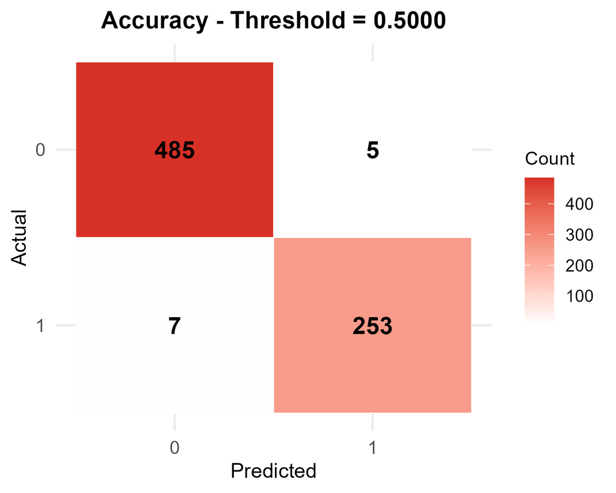

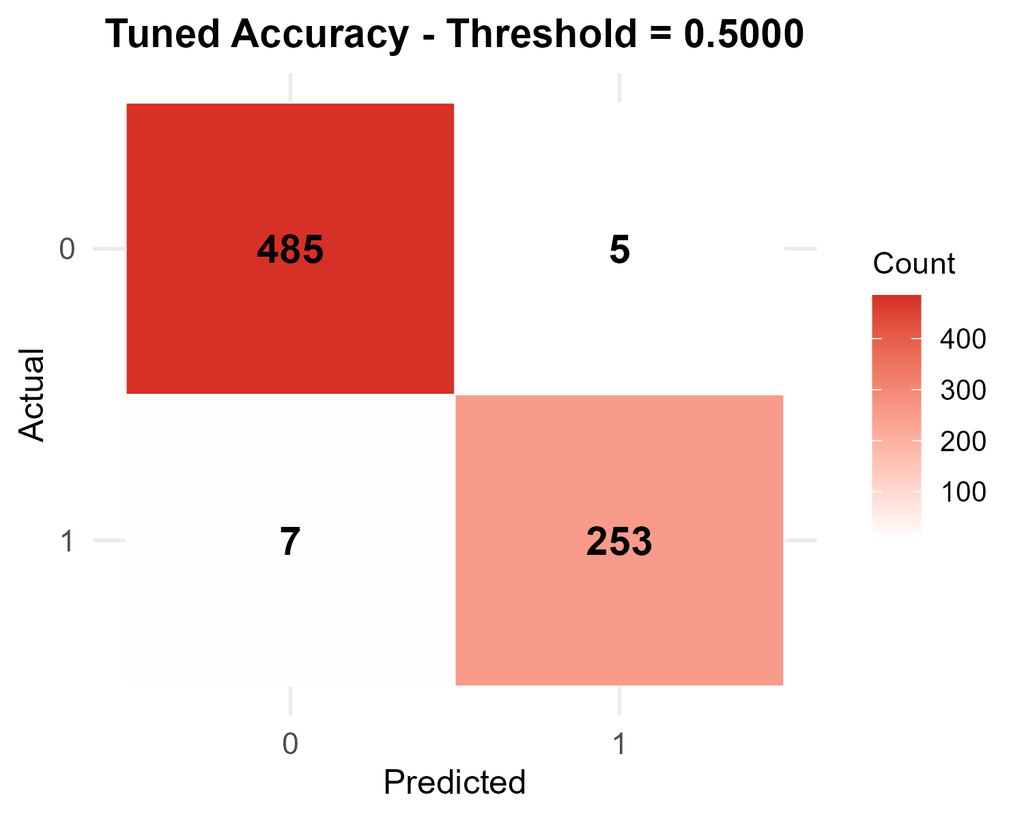

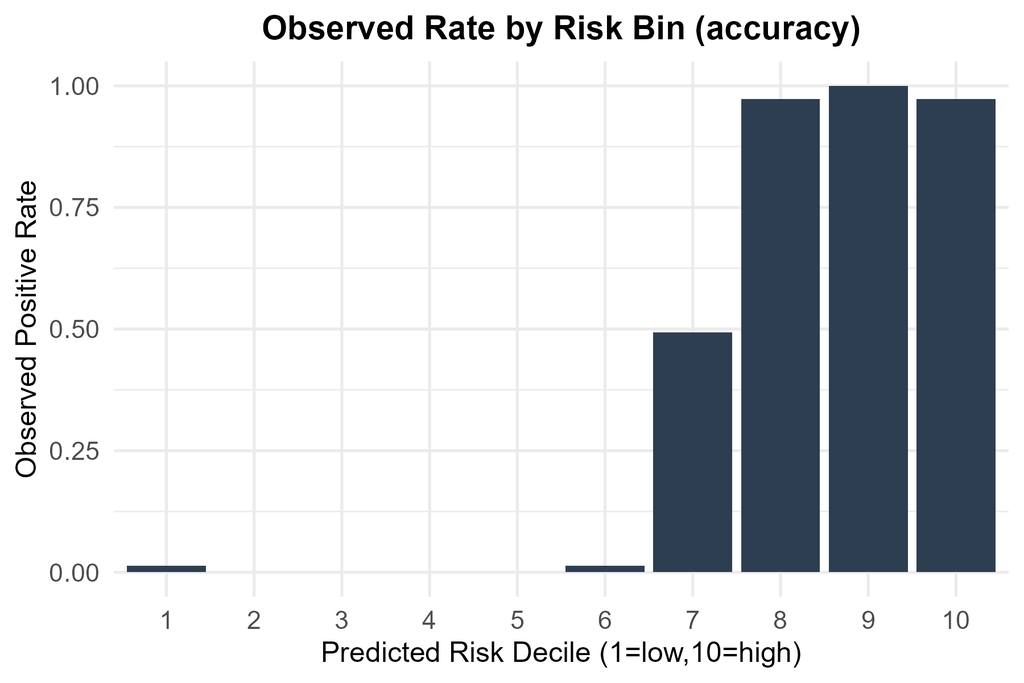

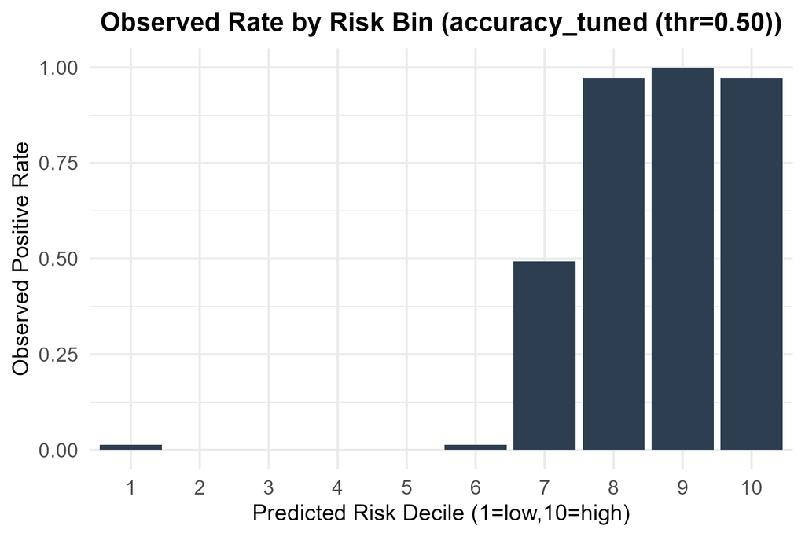

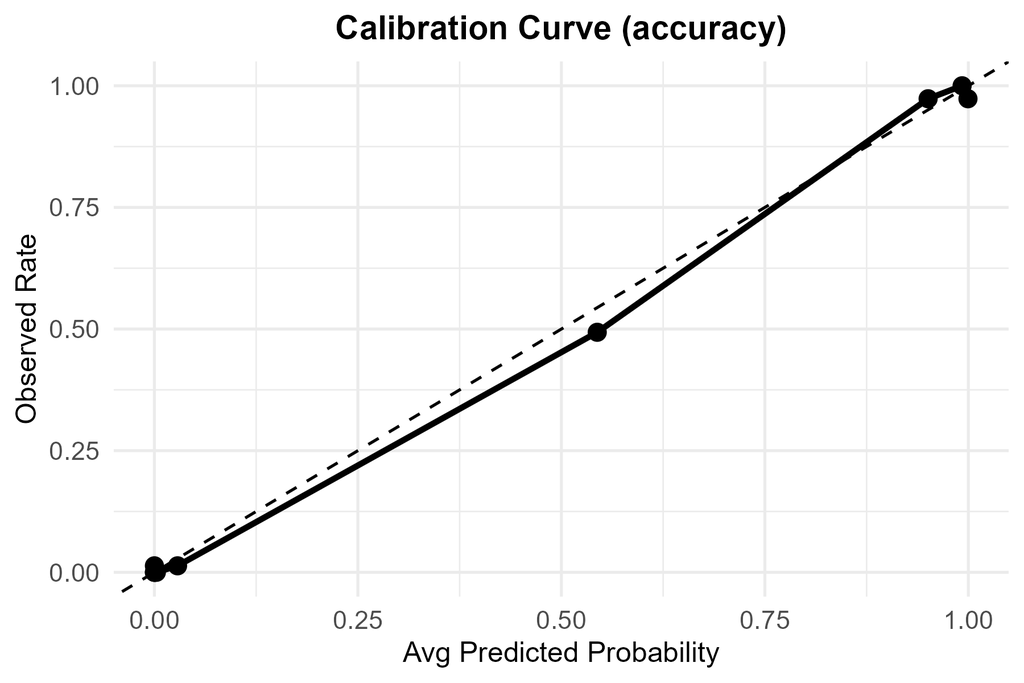

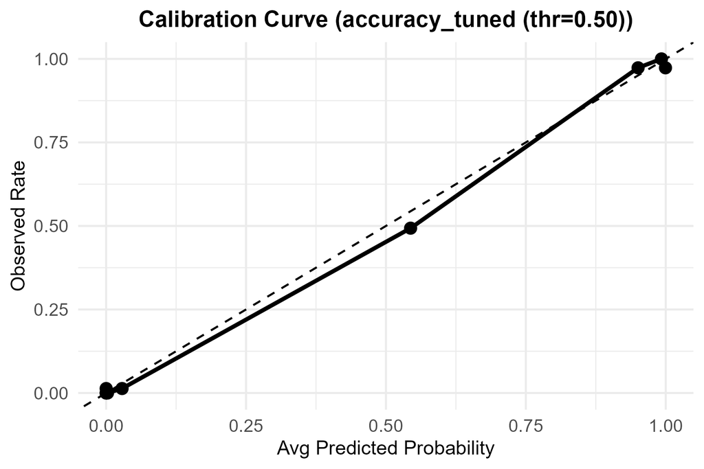

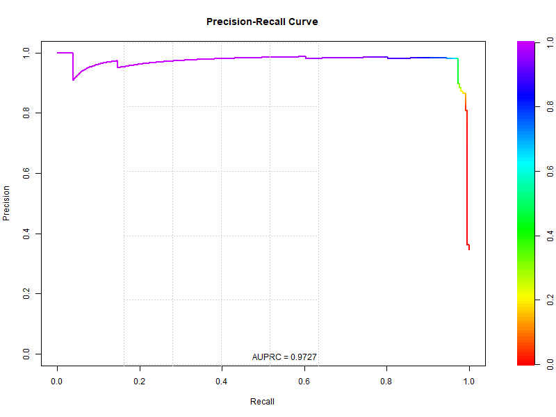

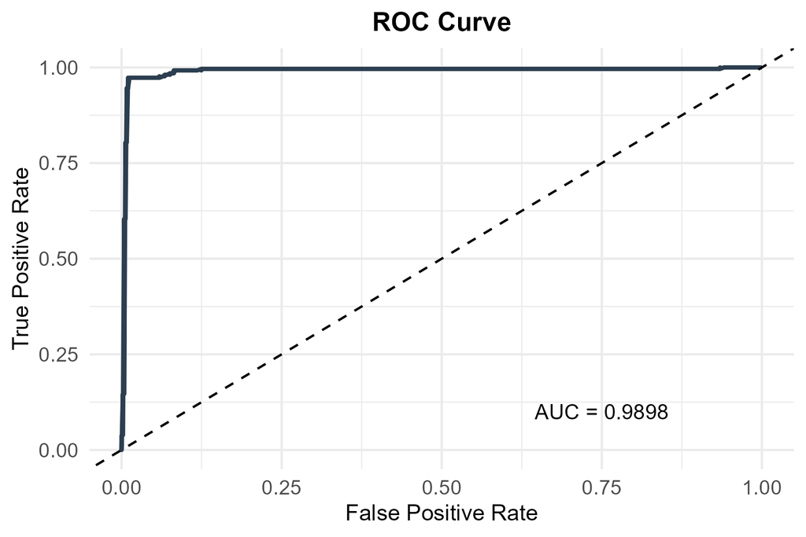

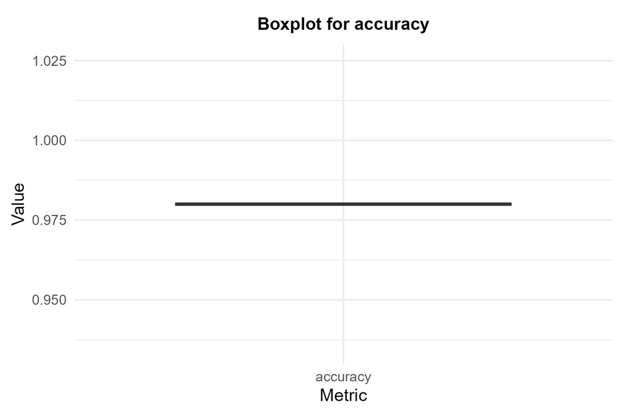

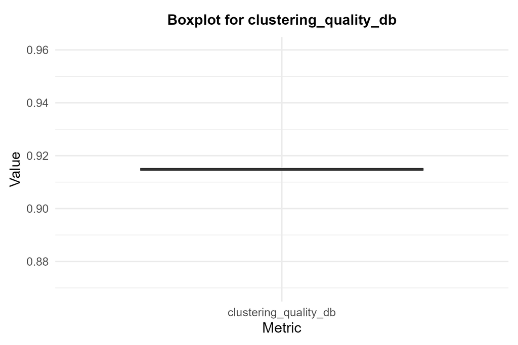

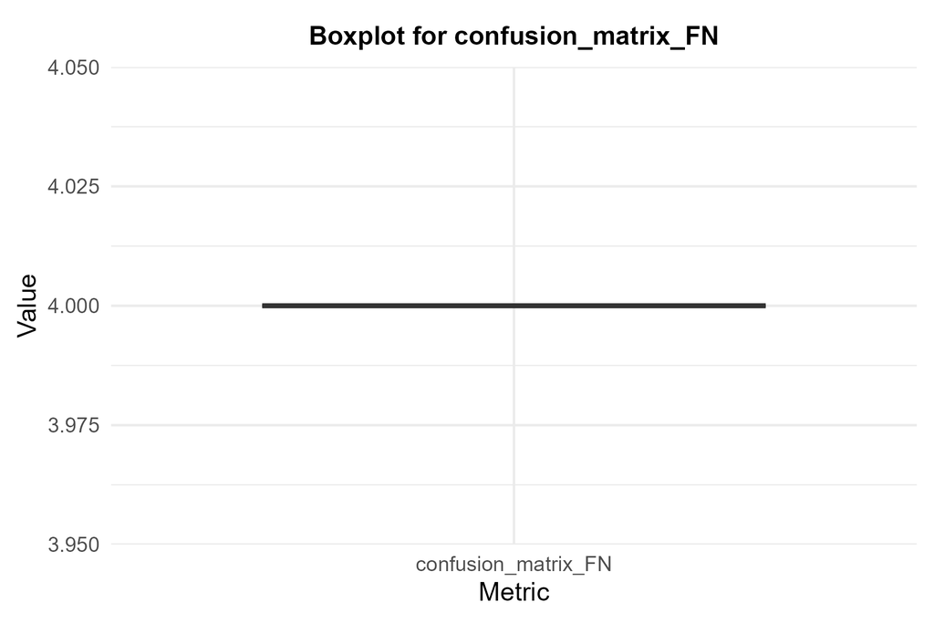

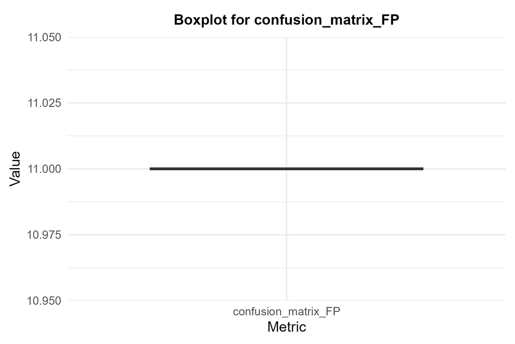

[50 more figures not shown]

## Scenario 2 — One `plot_controls` umbrella (Single Run: Scenario A)

```r
options(DDESONN_OUTPUT_ROOT = out2)
Sys.setenv(DDESONN_ARTIFACTS_ROOT = out2)

res_scenarioA_s2 <- ddesonn_run(
  x = x_train,
  y = y_train,
  classification_mode = "binary",
  hidden_sizes = c(64, 32),
  seeds = 1L,
  do_ensemble = FALSE,
  validation = list(x = x_valid, y = y_valid),
  test       = list(x = x_test,  y = y_test),
  training_overrides = list(
    init_method = "he",
    optimizer = "adagrad",
    lr = 0.125,
    lambda = 0.00028,
    activation_functions = list(relu, relu, sigmoid),
    dropout_rates = list(0.10),
    loss_type = "CrossEntropy",
    validation_metrics = TRUE,
    num_epochs = 1,
    final_summary_decimals = 6L
  ),
  plot_controls = list(
    per_epoch = list(
      saveEnabled = TRUE,
      loss_curve = TRUE,
      probe_plots = TRUE,
      verbose = TRUE
    ),

    # ============================================================
    # #$$$$$$$$$$$$$ SECTION: performance_relevance (Scenario 2)
    # ============================================================
    performance_relevance = list(                                                       #$$$$$$$$$$$$$
      saveEnabled = TRUE,                                                               #$$$$$$$$$$$$$
      viewAllPlots = FALSE,                                                             #$$$$$$$$$$$$$
      performance_high_mean_plots = TRUE,                                                #$$$$$$$$$$$$$
      performance_low_mean_plots  = TRUE,                                                #$$$$$$$$$$$$$
      relevance_high_mean_plots   = TRUE,                                                #$$$$$$$$$$$$$
      relevance_low_mean_plots    = TRUE,                                                #$$$$$$$$$$$$$
      verbose = TRUE                                                                    #$$$$$$$$$$$$$
    ),                                                                                  #$$$$$$$$$$$$$

    evaluate_report = list(
      accuracy_plot = TRUE,
      accuracy_plot_mode = "both",
      plot_roc = TRUE,
      plot_pr  = TRUE,
      show_auprc = TRUE,
      viewAllPlots = FALSE,
      verbose = TRUE
    )
  )
)
```

[output not shown]

```
## [PR] performance_high_mean_plots class=list length=9 names(head)=confusion_matrix_TP,confusion_matrix_FP,confusion_matrix_TN,confusion_matrix_FN,accuracy_precision_recall_f1_tuned_confusion_matrix_TP
## [PR TRACE] CALL low(perf)
```

```
## [PR] performance_low_mean_plots class=list length=18 names(head)=quantization_error,topographic_error,clustering_quality_db,MSE,MAE
## [PR TRACE] CALL high(relev)
## [PR] relevance_high_mean_plots class=list length=0
## [PR TRACE] CALL low(relev)
```

```
## [PR] relevance_low_mean_plots class=list length=3 names(head)=ndcg,diversity,serendipity
```

[output not shown]

[output cut: 198 more lines]

[output not shown]

## Scenario 2 — Saved plots

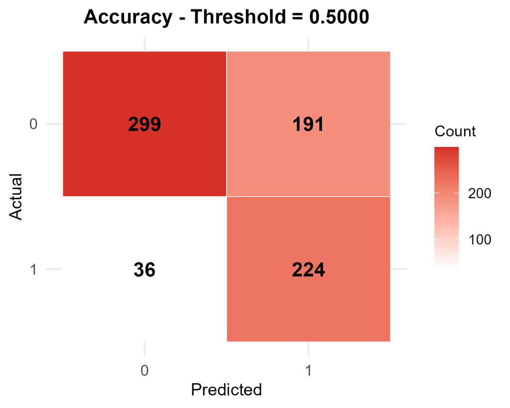

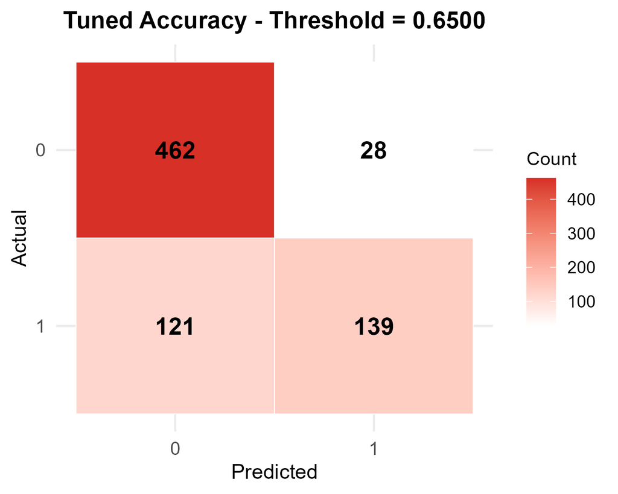

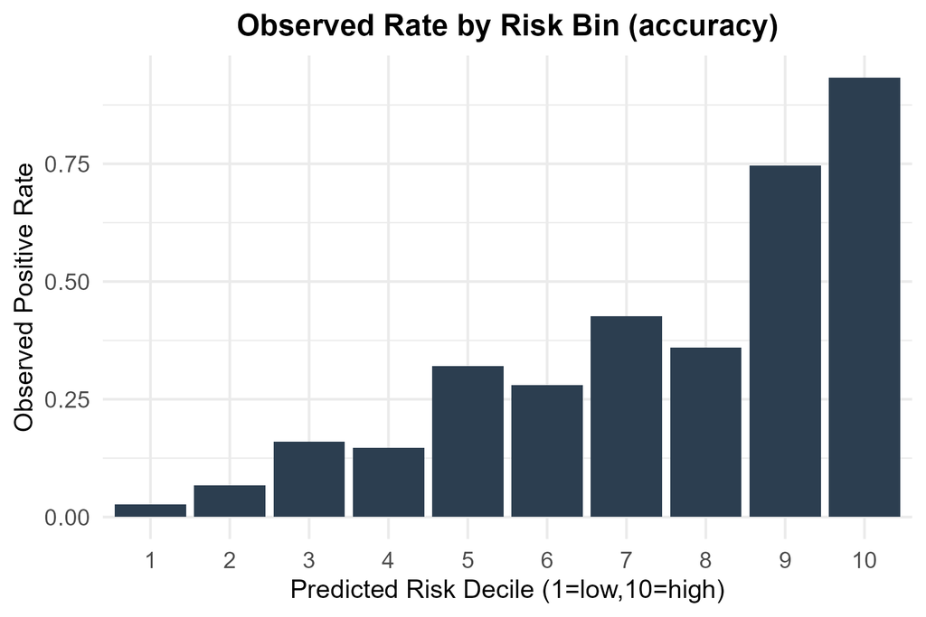

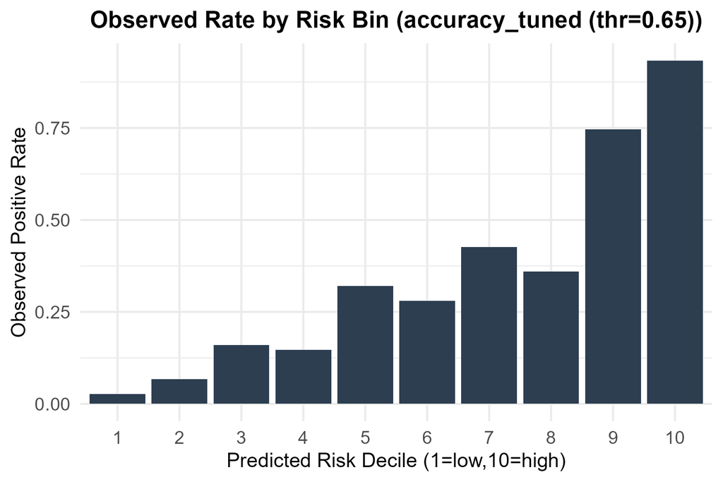

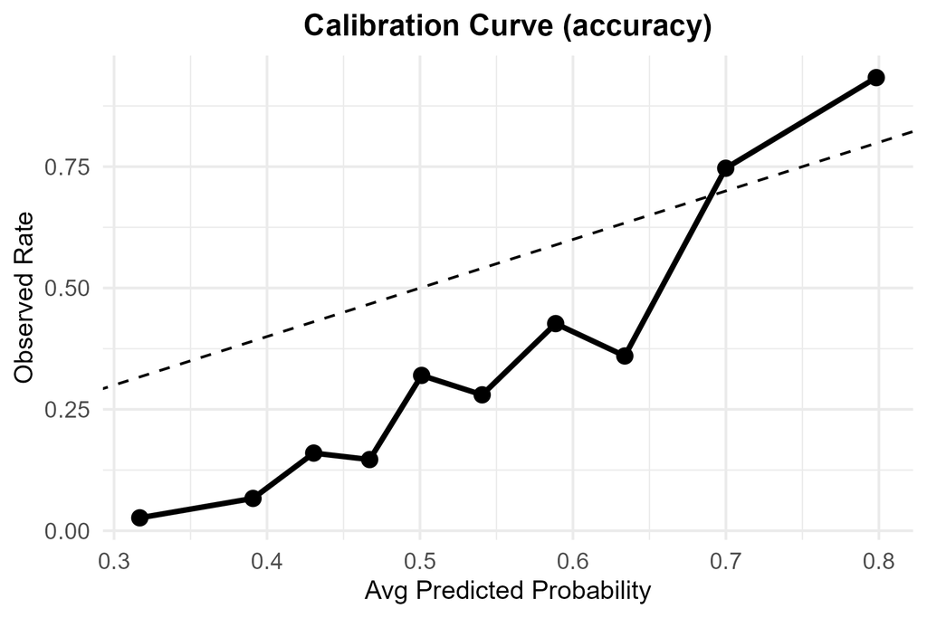

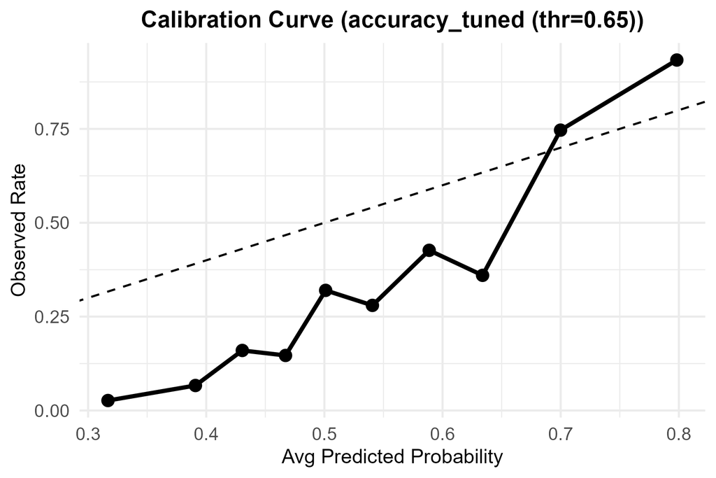

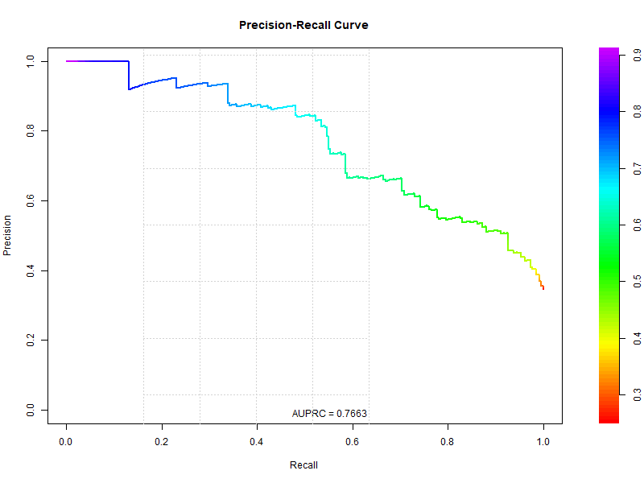

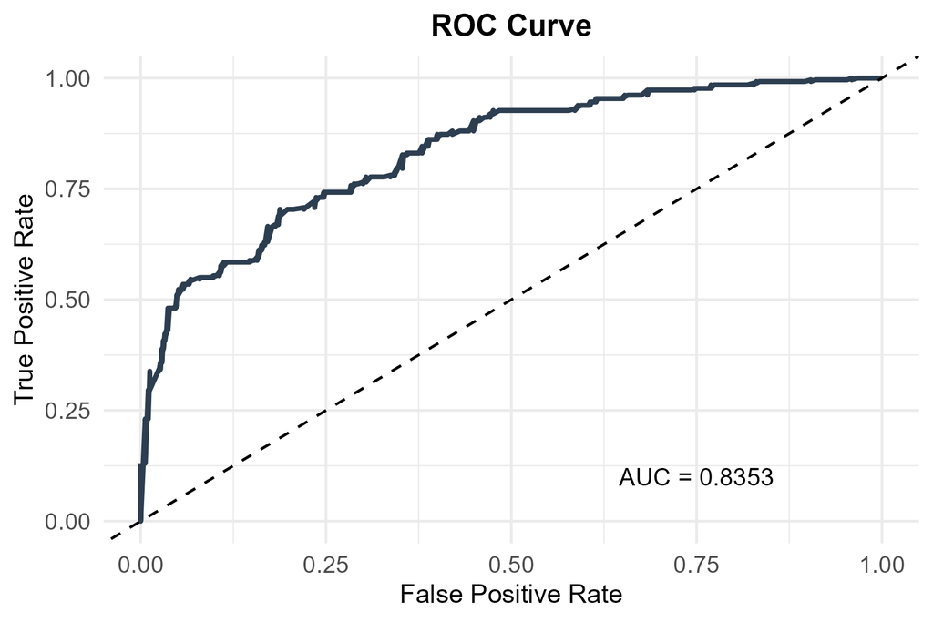

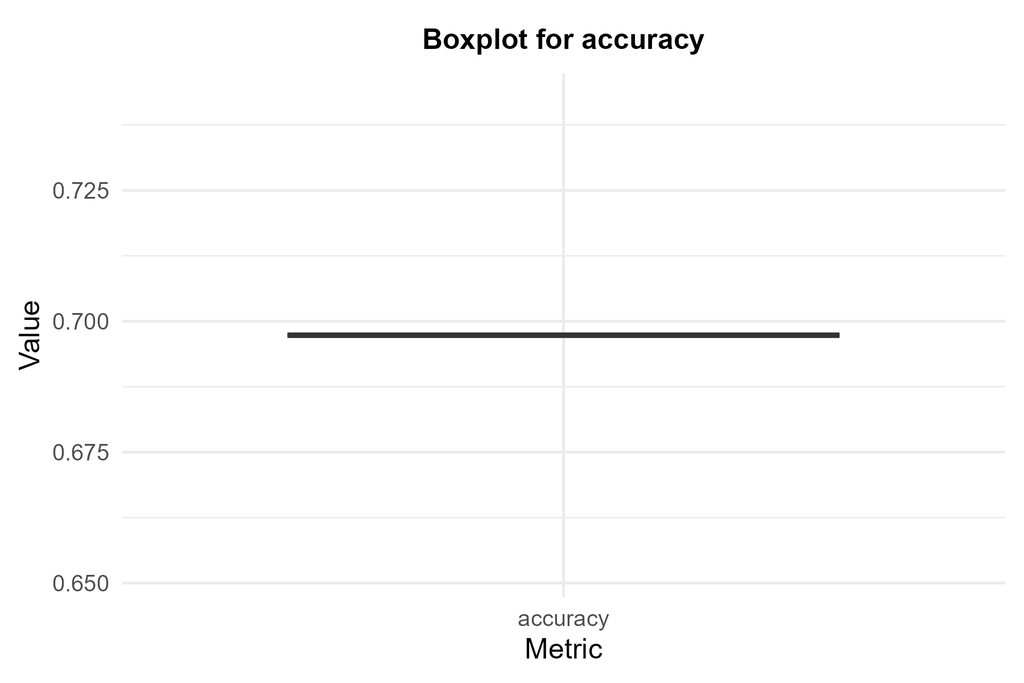

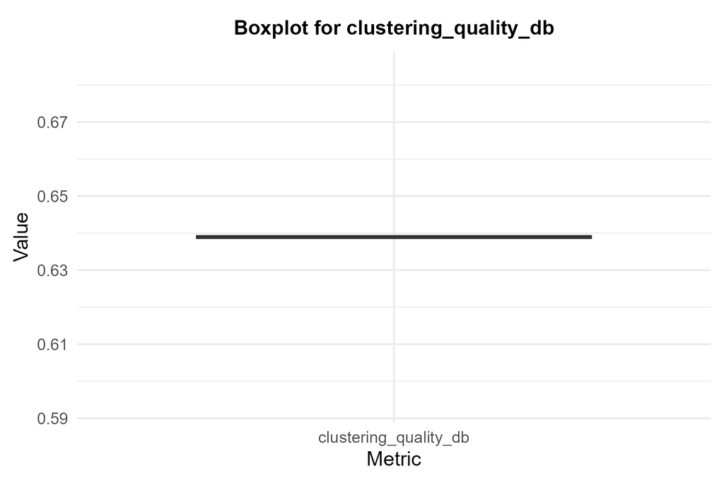

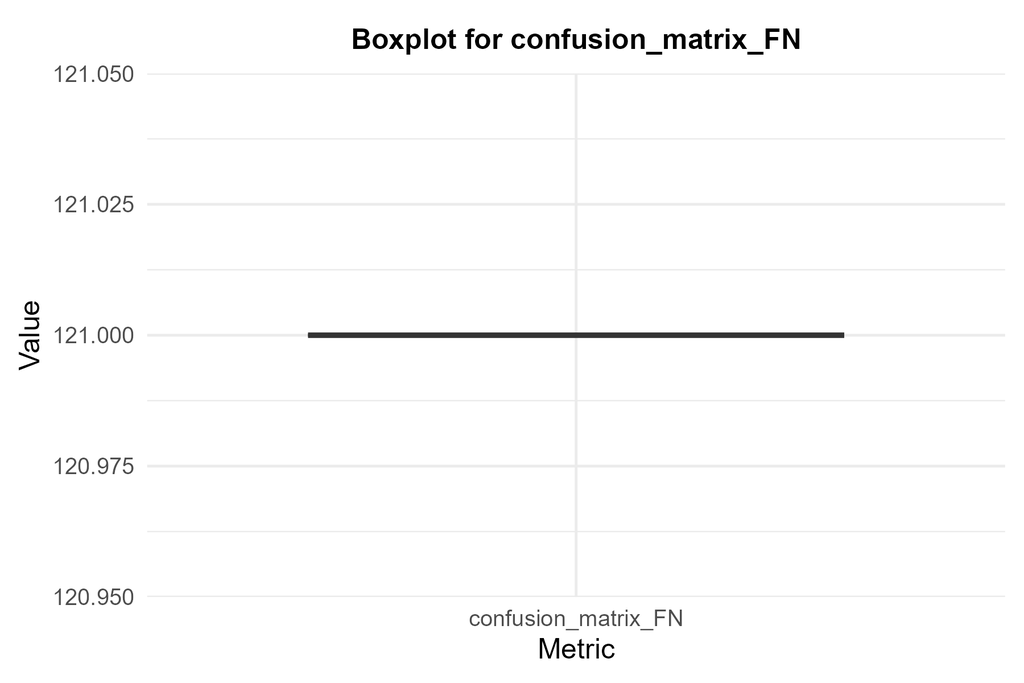

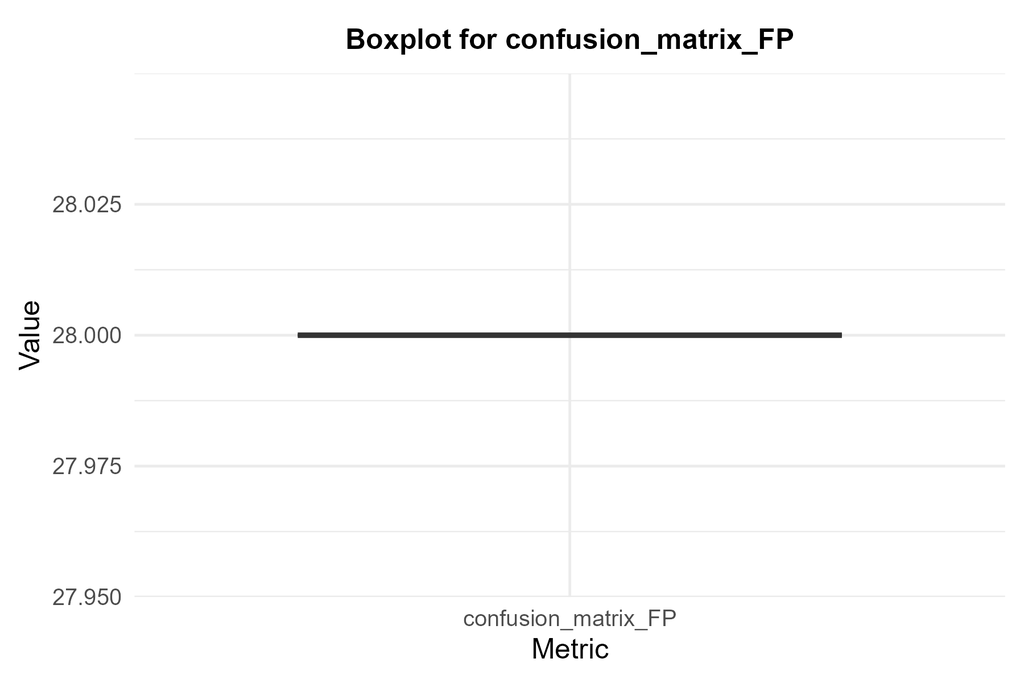

[36 more figures not shown]